# Sensor data description

DIME

13/12/2020

# 1 Summary

- This document describes the sensor data for the matatu the sensor is placed in. We have been testing two sensors since September. Over the last 4 weeks, we have been trying to test different platforms to download the data from in order to get a dataset at the vehicle-time level which updates every 10 seconds.
- Since we have been moving platforms, here we show the summary of 10 days of data in the last week of October and 2nd week for November.

# 2 Number of days of data

- Data for days:
- – Oct 22- Oct 27 and,  
  – Nov 11,12,13,19.
- The sensor is on Alfred’s car and a Matatu. This document has the information on the matatu.
- Gaps in data collection exists since we were trying 2-3 different platforms to store data on.
- Overall, the main variables of interest for us are the:  
  -lat/lon,  
  -speed,  
  -harsh braking (dummy and magnitude)
- Lat/lon, speed seem to be alright and making sense overall.
- We need to bring up the following: – Dates for which there are 0 values for speed and other variables,  
  – Meaning if harsh braking/harsh acceleration is 0

```r
# Speed over time
sensor_data_days <- ggplot(sensor, aes(x=Time, y=Speed)) +
  geom_line(color="#69b3a2",  linetype=2) +
theme_ipsum()
```

# 3 Variable summary

## 3.1 Speed

- We suspect the 0 in speed can be a combination of :  
  – Less matatu movement due to covid,  
  – They were having some technical issue in the device in the last week of October, first week of November due to which the device was not collecting any data.  
  – We will make sure to check the reasons for this with Sam.

```r
sensor$speed_dum <- ifelse(sensor$Speed == 0, 1, 0)
kable(table(sensor$date, sensor$speed_dum), col.names = c("Non-zero speed", "Zero speed"), caption = "Speed = 0 km/h by date") %>%
  kable_styling(bootstrap_options = c("striped", "hover"))
```

Speed = 0 km/h by date

|  | Non-zero speed | Zero speed |
| --- | --- | --- |
| 2020-10-22 | 4 | 1 |
| 2020-10-23 | 2095 | 208 |
| 2020-10-24 | 2352 | 437 |
| 2020-10-25 | 4096 | 432 |
| 2020-10-26 | 4178 | 399 |
| 2020-10-27 | 3487 | 337 |
| 2020-11-11 | 0 | 571 |
| 2020-11-12 | 3756 | 8433 |
| 2020-11-13 | 1436 | 2529 |
| 2020-11-19 | 1360 | 824 |

## 3.2 Harsh Acceleration

- Values represent magnitudes of harsh acceleration.
- Values are being shown only when speed is non-zero

```r
speed_valid <- subset(sensor, sensor$Speed != 0)
kable(table(speed_valid$date, speed_valid$`Harsh Acceleration*`), caption = "Harsh Acceleration values by Date") %>%
  kable_styling(bootstrap_options = c("striped", "hover"))
```

Harsh Acceleration values by Date

|  | —- | 0.16 | 0.28 | 0.31 |
| --- | --- | --- | --- | --- |
| 2020-10-22 | 4 | 0 | 0 | 0 |
| 2020-10-23 | 2095 | 0 | 0 | 0 |
| 2020-10-24 | 2352 | 0 | 0 | 0 |
| 2020-10-25 | 4096 | 0 | 0 | 0 |
| 2020-10-26 | 4178 | 0 | 0 | 0 |
| 2020-10-27 | 3486 | 1 | 0 | 0 |
| 2020-11-12 | 3756 | 0 | 0 | 0 |
| 2020-11-13 | 1436 | 0 | 0 | 0 |
| 2020-11-19 | 1358 | 0 | 1 | 1 |

## 3.3 Harsh Braking

- Values represent magnitude of harsh braking
- For instance 0.31 is harsher than 0.16
- Values are being shown only when speed is non-zero

```r
library(knitr)
library(kableExtra)

kable(table(speed_valid$date, speed_valid$`Harsh Braking*`), caption = "Harsh Braking values by Date") %>%
  kable_styling(bootstrap_options = c("striped", "hover"))
```

Harsh Braking values by Date

|  | —- | 0.00 | 0.19 | 0.22 | 0.25 | 0.28 | 0.31 | 0.33 | 0.36 | 0.42 | 0.50 | 0.65 |
| --- | --- | --- | --- | --- | --- | --- | --- | --- | --- | --- | --- | --- |
| 2020-10-22 | 4 | 0 | 0 | 0 | 0 | 0 | 0 | 0 | 0 | 0 | 0 | 0 |
| 2020-10-23 | 2095 | 0 | 0 | 0 | 0 | 0 | 0 | 0 | 0 | 0 | 0 | 0 |
| 2020-10-24 | 2352 | 0 | 0 | 0 | 0 | 0 | 0 | 0 | 0 | 0 | 0 | 0 |
| 2020-10-25 | 4096 | 0 | 0 | 0 | 0 | 0 | 0 | 0 | 0 | 0 | 0 | 0 |
| 2020-10-26 | 4162 | 0 | 0 | 0 | 0 | 7 | 4 | 2 | 0 | 1 | 2 | 0 |
| 2020-10-27 | 3453 | 0 | 3 | 4 | 1 | 19 | 5 | 1 | 0 | 0 | 0 | 1 |
| 2020-11-12 | 3747 | 9 | 0 | 0 | 0 | 0 | 0 | 0 | 0 | 0 | 0 | 0 |
| 2020-11-13 | 1424 | 12 | 0 | 0 | 0 | 0 | 0 | 0 | 0 | 0 | 0 | 0 |
| 2020-11-19 | 1346 | 2 | 0 | 0 | 0 | 0 | 8 | 3 | 1 | 0 | 0 | 0 |

## 3.4 Harsh Cornering

- Missing for all
- Values are being shown only when speed is non-zero

```r
library(knitr)
library(kableExtra)

kable(table(speed_valid$date, speed_valid$`Harsh Cornering*`), caption = "Harsh Cornering values by Date") %>%
  kable_styling(bootstrap_options = c("striped", "hover"))
```

Harsh Cornering values by Date

|  | —- |
| --- | --- |
| 2020-10-22 | 4 |
| 2020-10-23 | 2095 |
| 2020-10-24 | 2352 |
| 2020-10-25 | 4096 |
| 2020-10-26 | 4178 |
| 2020-10-27 | 3487 |
| 2020-11-12 | 3756 |
| 2020-11-13 | 1436 |
| 2020-11-19 | 1360 |

## 3.5 Ignition

*Dummy whether ignition was on or off

```r
library(knitr)
library(kableExtra)

kable(table(speed_valid$date, speed_valid$`Ignition*`), caption = "Ignition (On/Off) by Date") %>%
  kable_styling(bootstrap_options = c("striped", "hover"))
```

Ignition (On/Off) by Date

|  | Off | On |
| --- | --- | --- |
| 2020-10-22 | 0 | 4 |
| 2020-10-23 | 43 | 2052 |
| 2020-10-24 | 93 | 2259 |
| 2020-10-25 | 46 | 4050 |
| 2020-10-26 | 26 | 4152 |
| 2020-10-27 | 0 | 3487 |
| 2020-11-12 | 6 | 3750 |
| 2020-11-13 | 0 | 1436 |
| 2020-11-19 | 69 | 1291 |

## 3.6 Braking - Event dummy

- Dummy whether braking occurred or not
- Not sure of this variable, does it turn on when any brake is applied or when vehicle comes to a halt?
- Need to check whether is braking dummy or harsh braking dummy
- Values are being shown for all data and for the subset of values when speed is non-zero.

```r
library(knitr)
library(kableExtra)

kable(table(speed_valid$date, speed_valid$`Event: braking*`), caption = "Braking event by Date (Speed (Non-zero)") %>%
  kable_styling(bootstrap_options = c("striped", "hover"))
```

Braking event by Date (Speed (Non-zero)

|  | —- | Off | On |
| --- | --- | --- | --- |
| 2020-10-22 | 4 | 0 | 0 |
| 2020-10-23 | 2095 | 0 | 0 |
| 2020-10-24 | 2352 | 0 | 0 |
| 2020-10-25 | 4096 | 0 | 0 |
| 2020-10-26 | 4162 | 0 | 16 |
| 2020-10-27 | 3452 | 1 | 34 |
| 2020-11-12 | 3747 | 0 | 9 |
| 2020-11-13 | 1424 | 0 | 12 |
| 2020-11-19 | 1344 | 2 | 14 |

```r
kable(table(sensor$date, sensor$`Event: braking*`), caption = "Braking event by Date (Speed includes zero)") %>%
  kable_styling(bootstrap_options = c("striped", "hover"))
```

Braking event by Date (Speed includes zero)

|  | —- | Off | On |
| --- | --- | --- | --- |
| 2020-10-22 | 5 | 0 | 0 |
| 2020-10-23 | 2303 | 0 | 0 |
| 2020-10-24 | 2789 | 0 | 0 |
| 2020-10-25 | 4528 | 0 | 0 |
| 2020-10-26 | 4561 | 0 | 16 |
| 2020-10-27 | 3789 | 1 | 34 |
| 2020-11-11 | 571 | 0 | 0 |
| 2020-11-12 | 12180 | 0 | 9 |
| 2020-11-13 | 3953 | 0 | 12 |
| 2020-11-19 | 2168 | 2 | 14 |

## 3.7 Acceleration - Event dummy

- Dummy whether harsh acceleration happened
- Values are being shown only when speed is non-zero

```r
library(knitr)
library(kableExtra)

kable(table(speed_valid$date, speed_valid$`Event: acceleration*`), caption = "Speeding event by Date") %>%
  kable_styling(bootstrap_options = c("striped", "hover"))
```

Speeding event by Date

|  | —- | Off | On (harsh acceleration) |
| --- | --- | --- | --- |
| 2020-10-22 | 4 | 0 | 0 |
| 2020-10-23 | 2095 | 0 | 0 |
| 2020-10-24 | 2352 | 0 | 0 |
| 2020-10-25 | 4096 | 0 | 0 |
| 2020-10-26 | 4162 | 16 | 0 |
| 2020-10-27 | 3452 | 34 | 1 |
| 2020-11-12 | 3747 | 9 | 0 |
| 2020-11-13 | 1424 | 12 | 0 |
| 2020-11-19 | 1344 | 14 | 2 |

# 4 Speed over time for 19th November 2020

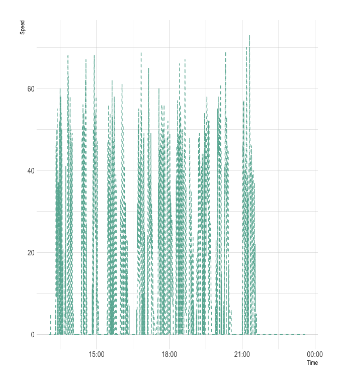

```r
subset <- subset(sensor, sensor$date == "2020-11-19")
sensor_data_19 <- ggplot(subset, aes(x=Time, y=Speed)) +
  geom_line(color="#69b3a2",  linetype=2) +
theme_ipsum()
print(sensor_data_19)
```

# 5 Speed tracing between 15:00 - 17:00 19th November 2020

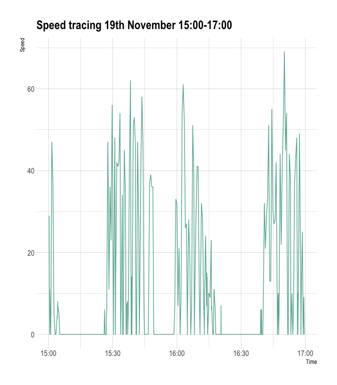

```r
time_subset <- subset(subset, subset = hour %in% c(15,16))
sensor_data_15 <- ggplot(time_subset, aes(x=Time, y=Speed)) +
  geom_line(color="#69b3a2",  linetype=1) +
  ggtitle("Speed tracing 19th November 15:00-17:00") +
theme_ipsum()
print(sensor_data_15)
```

# 6 Map of route on 4 days

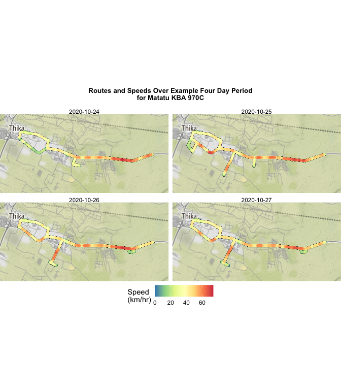

```r
ggmap(basemap) +
  geom_point(data = sensor %>%
               filter(date %in% as.Date(c("2020-10-24",
                                          "2020-10-25",
                                          "2020-10-26",
                                          "2020-10-27"))) %>%
               arrange(Speed),
             aes(x = lon, y=lat),
             size = 1.2,
             color = "black") +
  geom_point(data = sensor %>%
               filter(date %in% as.Date(c("2020-10-24",
                                        "2020-10-25",
                                        "2020-10-26",
                                        "2020-10-27"))) %>%
               arrange(Speed),
             aes(x = lon, y=lat, color = Speed),
             size = 1) +

  labs(title = "Routes and Speeds Over Example Four Day Period\nfor Matatu KBA 970C\n",
       color = "Speed\n(km/hr)") +
  scale_color_gradientn(colours = rev(brewer.pal(n = 7, name = "Spectral"))) +
  theme_void() +
  theme(plot.title = element_text(hjust = 0.5,
                                  face = "bold",
                                  size = 10),
        legend.position = "bottom") +
  facet_wrap(~date)
```